# Risk Factor Analysis

## Outcome Variable

**Outcome Variable:** wasted

## Predictor Variables

**Intervention Variable:** enwast

**Adjustment Set:**

- arm
- sex
- W_mage
- meducyrs
- feducyrs
- hhwealth_quart
- vagbrth
- W_nrooms
- brthmon
- W_parity
- impfloor
- impsan
- safeh20
- delta_W_mage
- delta_meducyrs
- delta_feducyrs
- delta_hhwealth_quart
- delta_vagbrth
- delta_W_nrooms
- delta_brthmon
- delta_W_parity
- delta_impfloor
- delta_impsan
- delta_safeh20

## Stratifying Variables

The analysis was stratified on these variable(s):

- agecat
- studyid
- country

## Data Summary

| agecat | studyid | country | enwast | wasted | n_cell | n |
| --- | --- | --- | --- | --- | --- | --- |
| Birth | ki0047075b-MAL-ED | BANGLADESH | 0 | 0 | 201 | 241 |
| Birth | ki0047075b-MAL-ED | BANGLADESH | 0 | 1 | 0 | 241 |
| Birth | ki0047075b-MAL-ED | BANGLADESH | 1 | 0 | 0 | 241 |
| Birth | ki0047075b-MAL-ED | BANGLADESH | 1 | 1 | 40 | 241 |
| Birth | ki0047075b-MAL-ED | BRAZIL | 0 | 0 | 177 | 183 |
| Birth | ki0047075b-MAL-ED | BRAZIL | 0 | 1 | 0 | 183 |
| Birth | ki0047075b-MAL-ED | BRAZIL | 1 | 0 | 0 | 183 |
| Birth | ki0047075b-MAL-ED | BRAZIL | 1 | 1 | 6 | 183 |
| Birth | ki0047075b-MAL-ED | INDIA | 0 | 0 | 170 | 203 |
| Birth | ki0047075b-MAL-ED | INDIA | 0 | 1 | 0 | 203 |
| Birth | ki0047075b-MAL-ED | INDIA | 1 | 0 | 0 | 203 |
| Birth | ki0047075b-MAL-ED | INDIA | 1 | 1 | 33 | 203 |
| Birth | ki0047075b-MAL-ED | NEPAL | 0 | 0 | 148 | 168 |
| Birth | ki0047075b-MAL-ED | NEPAL | 0 | 1 | 0 | 168 |
| Birth | ki0047075b-MAL-ED | NEPAL | 1 | 0 | 0 | 168 |
| Birth | ki0047075b-MAL-ED | NEPAL | 1 | 1 | 20 | 168 |
| Birth | ki0047075b-MAL-ED | PERU | 0 | 0 | 273 | 279 |
| Birth | ki0047075b-MAL-ED | PERU | 0 | 1 | 0 | 279 |
| Birth | ki0047075b-MAL-ED | PERU | 1 | 0 | 0 | 279 |
| Birth | ki0047075b-MAL-ED | PERU | 1 | 1 | 6 | 279 |
| Birth | ki0047075b-MAL-ED | SOUTH AFRICA | 0 | 0 | 240 | 258 |
| Birth | ki0047075b-MAL-ED | SOUTH AFRICA | 0 | 1 | 0 | 258 |
| Birth | ki0047075b-MAL-ED | SOUTH AFRICA | 1 | 0 | 0 | 258 |
| Birth | ki0047075b-MAL-ED | SOUTH AFRICA | 1 | 1 | 18 | 258 |
| Birth | ki0047075b-MAL-ED | TANZANIA, UNITED REPUBLIC OF | 0 | 0 | 116 | 118 |
| Birth | ki0047075b-MAL-ED | TANZANIA, UNITED REPUBLIC OF | 0 | 1 | 0 | 118 |
| Birth | ki0047075b-MAL-ED | TANZANIA, UNITED REPUBLIC OF | 1 | 0 | 0 | 118 |
| Birth | ki0047075b-MAL-ED | TANZANIA, UNITED REPUBLIC OF | 1 | 1 | 2 | 118 |
| Birth | ki1000108-CMC-V-BCS-2002 | INDIA | 0 | 0 | 74 | 88 |
| Birth | ki1000108-CMC-V-BCS-2002 | INDIA | 0 | 1 | 0 | 88 |

[output cut: 314 more lines]

The following strata were considered:

- agecat: 24 months, studyid: ki0047075b-MAL-ED, country: BANGLADESH
- agecat: 24 months, studyid: ki0047075b-MAL-ED, country: BRAZIL
- agecat: 24 months, studyid: ki0047075b-MAL-ED, country: INDIA
- agecat: 24 months, studyid: ki0047075b-MAL-ED, country: NEPAL
- agecat: 24 months, studyid: ki0047075b-MAL-ED, country: PERU
- agecat: 24 months, studyid: ki0047075b-MAL-ED, country: SOUTH AFRICA
- agecat: 24 months, studyid: ki0047075b-MAL-ED, country: TANZANIA, UNITED REPUBLIC OF
- agecat: 24 months, studyid: ki1000108-CMC-V-BCS-2002, country: INDIA
- agecat: 24 months, studyid: ki1000108-IRC, country: INDIA
- agecat: 24 months, studyid: ki1017093-NIH-Birth, country: BANGLADESH
- agecat: 24 months, studyid: ki1017093b-PROVIDE, country: BANGLADESH
- agecat: 24 months, studyid: ki1017093c-NIH-Crypto, country: BANGLADESH
- agecat: 24 months, studyid: ki1066203-TanzaniaChild2, country: TANZANIA, UNITED REPUBLIC OF
- agecat: 24 months, studyid: ki1101329-Keneba, country: GAMBIA
- agecat: 24 months, studyid: ki1113344-GMS-Nepal, country: NEPAL
- agecat: 24 months, studyid: ki1114097-CMIN, country: BANGLADESH
- agecat: 24 months, studyid: ki1114097-CMIN, country: GUINEA-BISSAU
- agecat: 24 months, studyid: ki1114097-CMIN, country: PERU
- agecat: 24 months, studyid: ki1114097-CONTENT, country: PERU
- agecat: 24 months, studyid: ki1119695-PROBIT, country: BELARUS
- agecat: 24 months, studyid: ki1126311-ZVITAMBO, country: ZIMBABWE
- agecat: 24 months, studyid: ki1135781-COHORTS, country: GUATEMALA
- agecat: 24 months, studyid: ki1135781-COHORTS, country: INDIA
- agecat: 24 months, studyid: ki1135781-COHORTS, country: PHILIPPINES
- agecat: 24 months, studyid: ki1148112-LCNI-5, country: MALAWI
- agecat: 24 months, studyid: kiGH5241-JiVitA-3, country: BANGLADESH
- agecat: 24 months, studyid: kiGH5241-JiVitA-4, country: BANGLADESH
- agecat: 6 months, studyid: ki0047075b-MAL-ED, country: BANGLADESH
- agecat: 6 months, studyid: ki0047075b-MAL-ED, country: BRAZIL
- agecat: 6 months, studyid: ki0047075b-MAL-ED, country: INDIA
- agecat: 6 months, studyid: ki0047075b-MAL-ED, country: NEPAL
- agecat: 6 months, studyid: ki0047075b-MAL-ED, country: PERU
- agecat: 6 months, studyid: ki0047075b-MAL-ED, country: SOUTH AFRICA
- agecat: 6 months, studyid: ki0047075b-MAL-ED, country: TANZANIA, UNITED REPUBLIC OF
- agecat: 6 months, studyid: ki1000108-CMC-V-BCS-2002, country: INDIA
- agecat: 6 months, studyid: ki1000108-IRC, country: INDIA
- agecat: 6 months, studyid: ki1000109-EE, country: PAKISTAN
- agecat: 6 months, studyid: ki1000109-ResPak, country: PAKISTAN
- agecat: 6 months, studyid: ki1000304b-SAS-CompFeed, country: INDIA
- agecat: 6 months, studyid: ki1000304b-SAS-FoodSuppl, country: INDIA
- agecat: 6 months, studyid: ki1017093-NIH-Birth, country: BANGLADESH
- agecat: 6 months, studyid: ki1017093b-PROVIDE, country: BANGLADESH
- agecat: 6 months, studyid: ki1017093c-NIH-Crypto, country: BANGLADESH
- agecat: 6 months, studyid: ki1066203-TanzaniaChild2, country: TANZANIA, UNITED REPUBLIC OF
- agecat: 6 months, studyid: ki1101329-Keneba, country: GAMBIA
- agecat: 6 months, studyid: ki1112895-Guatemala BSC, country: GUATEMALA
- agecat: 6 months, studyid: ki1113344-GMS-Nepal, country: NEPAL
- agecat: 6 months, studyid: ki1114097-CMIN, country: BANGLADESH
- agecat: 6 months, studyid: ki1114097-CMIN, country: BRAZIL
- agecat: 6 months, studyid: ki1114097-CMIN, country: GUINEA-BISSAU
- agecat: 6 months, studyid: ki1114097-CMIN, country: PERU
- agecat: 6 months, studyid: ki1114097-CONTENT, country: PERU
- agecat: 6 months, studyid: ki1119695-PROBIT, country: BELARUS
- agecat: 6 months, studyid: ki1126311-ZVITAMBO, country: ZIMBABWE
- agecat: 6 months, studyid: ki1135781-COHORTS, country: GUATEMALA
- agecat: 6 months, studyid: ki1135781-COHORTS, country: INDIA
- agecat: 6 months, studyid: ki1135781-COHORTS, country: PHILIPPINES
- agecat: 6 months, studyid: ki1148112-LCNI-5, country: MALAWI
- agecat: 6 months, studyid: kiGH5241-JiVitA-3, country: BANGLADESH
- agecat: 6 months, studyid: kiGH5241-JiVitA-4, country: BANGLADESH
- agecat: Birth, studyid: ki0047075b-MAL-ED, country: BANGLADESH
- agecat: Birth, studyid: ki0047075b-MAL-ED, country: BRAZIL
- agecat: Birth, studyid: ki0047075b-MAL-ED, country: INDIA
- agecat: Birth, studyid: ki0047075b-MAL-ED, country: NEPAL
- agecat: Birth, studyid: ki0047075b-MAL-ED, country: PERU
- agecat: Birth, studyid: ki0047075b-MAL-ED, country: SOUTH AFRICA
- agecat: Birth, studyid: ki0047075b-MAL-ED, country: TANZANIA, UNITED REPUBLIC OF
- agecat: Birth, studyid: ki1000108-CMC-V-BCS-2002, country: INDIA
- agecat: Birth, studyid: ki1000108-IRC, country: INDIA
- agecat: Birth, studyid: ki1000109-EE, country: PAKISTAN
- agecat: Birth, studyid: ki1000109-ResPak, country: PAKISTAN
- agecat: Birth, studyid: ki1000304b-SAS-CompFeed, country: INDIA
- agecat: Birth, studyid: ki1017093-NIH-Birth, country: BANGLADESH
- agecat: Birth, studyid: ki1017093c-NIH-Crypto, country: BANGLADESH
- agecat: Birth, studyid: ki1101329-Keneba, country: GAMBIA
- agecat: Birth, studyid: ki1114097-CMIN, country: BANGLADESH
- agecat: Birth, studyid: ki1114097-CMIN, country: BRAZIL
- agecat: Birth, studyid: ki1114097-CMIN, country: PERU
- agecat: Birth, studyid: ki1114097-CONTENT, country: PERU
- agecat: Birth, studyid: ki1119695-PROBIT, country: BELARUS
- agecat: Birth, studyid: ki1126311-ZVITAMBO, country: ZIMBABWE
- agecat: Birth, studyid: ki1135781-COHORTS, country: GUATEMALA
- agecat: Birth, studyid: ki1135781-COHORTS, country: INDIA
- agecat: Birth, studyid: ki1135781-COHORTS, country: PHILIPPINES
- agecat: Birth, studyid: kiGH5241-JiVitA-3, country: BANGLADESH
- agecat: Birth, studyid: kiGH5241-JiVitA-4, country: BANGLADESH

### Dropped Strata

Some strata were dropped due to rare outcomes:

- agecat: Birth, studyid: ki0047075b-MAL-ED, country: BANGLADESH
- agecat: Birth, studyid: ki0047075b-MAL-ED, country: BRAZIL
- agecat: Birth, studyid: ki0047075b-MAL-ED, country: INDIA
- agecat: Birth, studyid: ki0047075b-MAL-ED, country: NEPAL
- agecat: Birth, studyid: ki0047075b-MAL-ED, country: PERU
- agecat: Birth, studyid: ki0047075b-MAL-ED, country: SOUTH AFRICA
- agecat: Birth, studyid: ki0047075b-MAL-ED, country: TANZANIA, UNITED REPUBLIC OF
- agecat: Birth, studyid: ki1000108-CMC-V-BCS-2002, country: INDIA
- agecat: Birth, studyid: ki1000108-IRC, country: INDIA
- agecat: Birth, studyid: ki1000109-EE, country: PAKISTAN
- agecat: Birth, studyid: ki1000109-ResPak, country: PAKISTAN
- agecat: Birth, studyid: ki1000304b-SAS-CompFeed, country: INDIA
- agecat: Birth, studyid: ki1017093-NIH-Birth, country: BANGLADESH
- agecat: Birth, studyid: ki1017093c-NIH-Crypto, country: BANGLADESH
- agecat: Birth, studyid: ki1101329-Keneba, country: GAMBIA
- agecat: Birth, studyid: ki1114097-CMIN, country: BANGLADESH
- agecat: Birth, studyid: ki1114097-CMIN, country: BRAZIL
- agecat: Birth, studyid: ki1114097-CMIN, country: PERU
- agecat: Birth, studyid: ki1114097-CONTENT, country: PERU
- agecat: Birth, studyid: ki1119695-PROBIT, country: BELARUS
- agecat: Birth, studyid: ki1126311-ZVITAMBO, country: ZIMBABWE
- agecat: Birth, studyid: ki1135781-COHORTS, country: GUATEMALA
- agecat: Birth, studyid: ki1135781-COHORTS, country: INDIA
- agecat: Birth, studyid: ki1135781-COHORTS, country: PHILIPPINES
- agecat: Birth, studyid: kiGH5241-JiVitA-3, country: BANGLADESH
- agecat: Birth, studyid: kiGH5241-JiVitA-4, country: BANGLADESH
- agecat: 6 months, studyid: ki0047075b-MAL-ED, country: BANGLADESH
- agecat: 6 months, studyid: ki0047075b-MAL-ED, country: BRAZIL
- agecat: 6 months, studyid: ki0047075b-MAL-ED, country: NEPAL
- agecat: 6 months, studyid: ki0047075b-MAL-ED, country: PERU
- agecat: 6 months, studyid: ki0047075b-MAL-ED, country: SOUTH AFRICA
- agecat: 6 months, studyid: ki0047075b-MAL-ED, country: TANZANIA, UNITED REPUBLIC OF
- agecat: 6 months, studyid: ki1112895-Guatemala BSC, country: GUATEMALA
- agecat: 6 months, studyid: ki1114097-CMIN, country: BRAZIL
- agecat: 6 months, studyid: ki1114097-CMIN, country: PERU
- agecat: 6 months, studyid: ki1114097-CONTENT, country: PERU
- agecat: 6 months, studyid: ki1148112-LCNI-5, country: MALAWI
- agecat: 24 months, studyid: ki0047075b-MAL-ED, country: BRAZIL
- agecat: 24 months, studyid: ki0047075b-MAL-ED, country: NEPAL
- agecat: 24 months, studyid: ki0047075b-MAL-ED, country: PERU
- agecat: 24 months, studyid: ki0047075b-MAL-ED, country: SOUTH AFRICA
- agecat: 24 months, studyid: ki0047075b-MAL-ED, country: TANZANIA, UNITED REPUBLIC OF
- agecat: 24 months, studyid: ki1066203-TanzaniaChild2, country: TANZANIA, UNITED REPUBLIC OF
- agecat: 24 months, studyid: ki1114097-CMIN, country: BANGLADESH
- agecat: 24 months, studyid: ki1114097-CMIN, country: PERU
- agecat: 24 months, studyid: ki1114097-CONTENT, country: PERU
- agecat: 24 months, studyid: ki1148112-LCNI-5, country: MALAWI

## Methods Detail

We’re interested in the causal parameters $E[Y_a]$ for all values of $a \in \mathcal{A}$. These parameters represent the mean outcome if, possibly contrary to fact, we intervened to set all units to have $A=a$. Under the randomization and positivity assumptions, these are identified by the statistical parameters $\psi_a=E_W[E_{Y|A,W}(Y|A=a,W)]$. In addition, we’re interested in the mean of $Y$, $E[Y]$ under no intervention (the observed mean). We will estimate these parameters by using SuperLearner to fit the relevant likelihood factors – $E_{Y|A,W}(Y|A=a,W)$ and $p(A=a|W)$, and then updating our likelihood fit using a joint TMLE.

For unadjusted analyses ($W=\{\}$), initial likelihoods were estimated using Lrnr_glm to estimate the simple $E(Y|A)$ and Lrnr_mean to estimate $p(A)$. For adjusted analyses, a small library containing Lrnr_glmnet, Lrnr_xgboost, and Lrnr_mean was used.

Having estimated these parameters, we will then use the delta method to estimate relative risks and attributable risks relative to a prespecified baseline level of $A$.

# Results Detail

## Results Plots

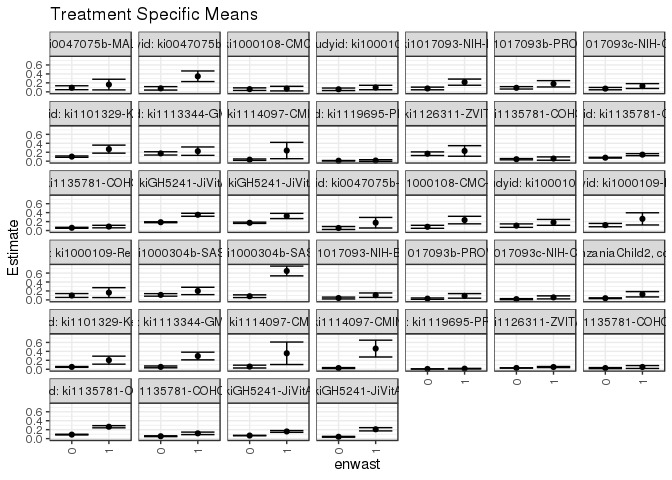

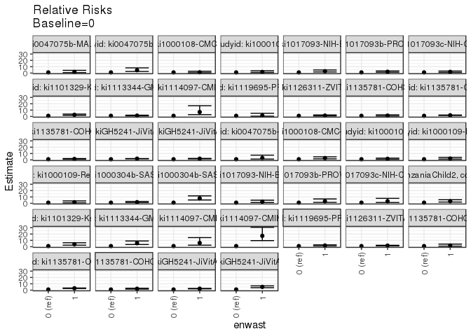

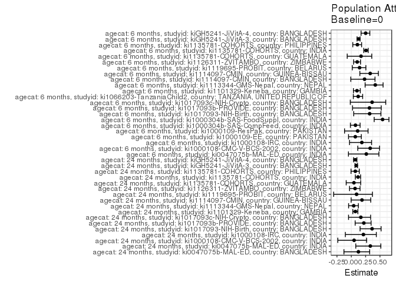

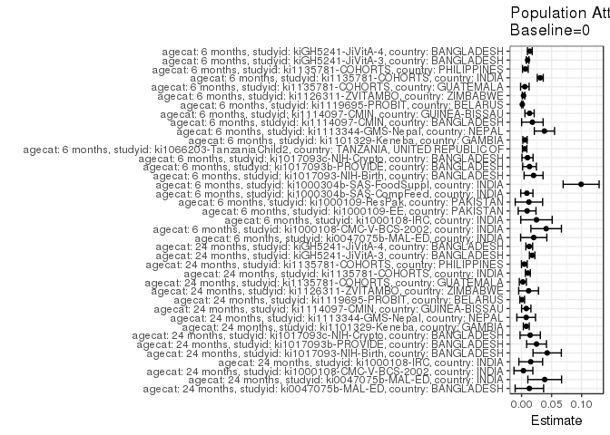

## Results Table

### Parameter: TSM

| agecat | studyid | country | intervention_level | baseline_level | estimate | ci_lower | ci_upper |
| --- | --- | --- | --- | --- | --- | --- | --- |
| 6 months | ki0047075b-MAL-ED | INDIA | 0 | NA | 0.0569948 | 0.0242171 | 0.0897725 |
| 6 months | ki0047075b-MAL-ED | INDIA | 1 | NA | 0.1750000 | 0.0569956 | 0.2930044 |
| 6 months | ki1000108-CMC-V-BCS-2002 | INDIA | 0 | NA | 0.0833630 | 0.0499827 | 0.1167432 |
| 6 months | ki1000108-CMC-V-BCS-2002 | INDIA | 1 | NA | 0.2344882 | 0.1504728 | 0.3185037 |
| 6 months | ki1000108-IRC | INDIA | 0 | NA | 0.1099269 | 0.0713533 | 0.1485006 |
| 6 months | ki1000108-IRC | INDIA | 1 | NA | 0.1827072 | 0.1172766 | 0.2481378 |
| 6 months | ki1000109-EE | PAKISTAN | 0 | NA | 0.1218937 | 0.0846201 | 0.1591673 |
| 6 months | ki1000109-EE | PAKISTAN | 1 | NA | 0.2610684 | 0.1242879 | 0.3978488 |
| 6 months | ki1000109-ResPak | PAKISTAN | 0 | NA | 0.0983607 | 0.0551180 | 0.1416033 |
| 6 months | ki1000109-ResPak | PAKISTAN | 1 | NA | 0.1627907 | 0.0522025 | 0.2733789 |
| 6 months | ki1000304b-SAS-CompFeed | INDIA | 0 | NA | 0.1118764 | 0.0836484 | 0.1401045 |
| 6 months | ki1000304b-SAS-CompFeed | INDIA | 1 | NA | 0.2001410 | 0.1176049 | 0.2826771 |
| 6 months | ki1000304b-SAS-FoodSuppl | INDIA | 0 | NA | 0.0824208 | 0.0521935 | 0.1126482 |
| 6 months | ki1000304b-SAS-FoodSuppl | INDIA | 1 | NA | 0.6467027 | 0.5372930 | 0.7561124 |
| 6 months | ki1017093-NIH-Birth | BANGLADESH | 0 | NA | 0.0424012 | 0.0216832 | 0.0631191 |
| 6 months | ki1017093-NIH-Birth | BANGLADESH | 1 | NA | 0.1055253 | 0.0561364 | 0.1549141 |
| 6 months | ki1017093b-PROVIDE | BANGLADESH | 0 | NA | 0.0285093 | 0.0132769 | 0.0437417 |
| 6 months | ki1017093b-PROVIDE | BANGLADESH | 1 | NA | 0.0899425 | 0.0388104 | 0.1410746 |
| 6 months | ki1017093c-NIH-Crypto | BANGLADESH | 0 | NA | 0.0174419 | 0.0061384 | 0.0287453 |
| 6 months | ki1017093c-NIH-Crypto | BANGLADESH | 1 | NA | 0.0561798 | 0.0223277 | 0.0900319 |
| 6 months | ki1066203-TanzaniaChild2 | TANZANIA, UNITED REPUBLIC OF | 0 | NA | 0.0378968 | 0.0293091 | 0.0464844 |
| 6 months | ki1066203-TanzaniaChild2 | TANZANIA, UNITED REPUBLIC OF | 1 | NA | 0.1259570 | 0.0664432 | 0.1854707 |
| 6 months | ki1101329-Keneba | GAMBIA | 0 | NA | 0.0520264 | 0.0422984 | 0.0617543 |
| 6 months | ki1101329-Keneba | GAMBIA | 1 | NA | 0.2033338 | 0.1143416 | 0.2923260 |
| 6 months | ki1113344-GMS-Nepal | NEPAL | 0 | NA | 0.0528399 | 0.0325847 | 0.0730950 |
| 6 months | ki1113344-GMS-Nepal | NEPAL | 1 | NA | 0.2960473 | 0.2098500 | 0.3822447 |
| 6 months | ki1114097-CMIN | BANGLADESH | 0 | NA | 0.0599078 | 0.0282641 | 0.0915515 |
| 6 months | ki1114097-CMIN | BANGLADESH | 1 | NA | 0.3571429 | 0.1056044 | 0.6086813 |
| 6 months | ki1114097-CMIN | GUINEA-BISSAU | 0 | NA | 0.0269521 | 0.0158714 | 0.0380328 |
| 6 months | ki1114097-CMIN | GUINEA-BISSAU | 1 | NA | 0.4621060 | 0.2740433 | 0.6501687 |
| 6 months | ki1119695-PROBIT | BELARUS | 0 | NA | 0.0070618 | 0.0058263 | 0.0082973 |
| 6 months | ki1119695-PROBIT | BELARUS | 1 | NA | 0.0133342 | 0.0073519 | 0.0193166 |
| 6 months | ki1126311-ZVITAMBO | ZIMBABWE | 0 | NA | 0.0290465 | 0.0249947 | 0.0330984 |
| 6 months | ki1126311-ZVITAMBO | ZIMBABWE | 1 | NA | 0.0498532 | 0.0381551 | 0.0615513 |
| 6 months | ki1135781-COHORTS | GUATEMALA | 0 | NA | 0.0266205 | 0.0149209 | 0.0383201 |
| 6 months | ki1135781-COHORTS | GUATEMALA | 1 | NA | 0.0506134 | 0.0187101 | 0.0825168 |
| 6 months | ki1135781-COHORTS | INDIA | 0 | NA | 0.0897440 | 0.0821080 | 0.0973799 |
| 6 months | ki1135781-COHORTS | INDIA | 1 | NA | 0.2653735 | 0.2409950 | 0.2897521 |
| 6 months | ki1135781-COHORTS | PHILIPPINES | 0 | NA | 0.0534860 | 0.0440696 | 0.0629023 |
| 6 months | ki1135781-COHORTS | PHILIPPINES | 1 | NA | 0.1180521 | 0.0899043 | 0.1462000 |
| 6 months | kiGH5241-JiVitA-3 | BANGLADESH | 0 | NA | 0.0688571 | 0.0639805 | 0.0737337 |
| 6 months | kiGH5241-JiVitA-3 | BANGLADESH | 1 | NA | 0.1601138 | 0.1405503 | 0.1796772 |
| 6 months | kiGH5241-JiVitA-4 | BANGLADESH | 0 | NA | 0.0410713 | 0.0316718 | 0.0504708 |
| 6 months | kiGH5241-JiVitA-4 | BANGLADESH | 1 | NA | 0.2088841 | 0.1727888 | 0.2449795 |
| 24 months | ki0047075b-MAL-ED | BANGLADESH | 0 | NA | 0.0914634 | 0.0472347 | 0.1356921 |
| 24 months | ki0047075b-MAL-ED | BANGLADESH | 1 | NA | 0.1621622 | 0.0430969 | 0.2812274 |
| 24 months | ki0047075b-MAL-ED | INDIA | 0 | NA | 0.0775362 | 0.0391590 | 0.1159135 |
| 24 months | ki0047075b-MAL-ED | INDIA | 1 | NA | 0.3474823 | 0.2288382 | 0.4661263 |
| 24 months | ki1000108-CMC-V-BCS-2002 | INDIA | 0 | NA | 0.0599251 | 0.0314166 | 0.0884336 |
| 24 months | ki1000108-CMC-V-BCS-2002 | INDIA | 1 | NA | 0.0714286 | 0.0203693 | 0.1224878 |
| 24 months | ki1000108-IRC | INDIA | 0 | NA | 0.0568934 | 0.0286539 | 0.0851330 |
| 24 months | ki1000108-IRC | INDIA | 1 | NA | 0.0963744 | 0.0465284 | 0.1462204 |
| 24 months | ki1017093-NIH-Birth | BANGLADESH | 0 | NA | 0.0750059 | 0.0450967 | 0.1049152 |
| 24 months | ki1017093-NIH-Birth | BANGLADESH | 1 | NA | 0.2163164 | 0.1474880 | 0.2851448 |
| 24 months | ki1017093b-PROVIDE | BANGLADESH | 0 | NA | 0.0891055 | 0.0626911 | 0.1155200 |
| 24 months | ki1017093b-PROVIDE | BANGLADESH | 1 | NA | 0.1794506 | 0.1087676 | 0.2501336 |
| 24 months | ki1017093c-NIH-Crypto | BANGLADESH | 0 | NA | 0.0716586 | 0.0452081 | 0.0981090 |
| 24 months | ki1017093c-NIH-Crypto | BANGLADESH | 1 | NA | 0.1291946 | 0.0748891 | 0.1835000 |
| 24 months | ki1101329-Keneba | GAMBIA | 0 | NA | 0.1022141 | 0.0875576 | 0.1168705 |
| 24 months | ki1101329-Keneba | GAMBIA | 1 | NA | 0.2692635 | 0.1799093 | 0.3586177 |
| 24 months | ki1113344-GMS-Nepal | NEPAL | 0 | NA | 0.1738095 | 0.1375319 | 0.2100871 |
| 24 months | ki1113344-GMS-Nepal | NEPAL | 1 | NA | 0.2236842 | 0.1299029 | 0.3174655 |
| 24 months | ki1114097-CMIN | GUINEA-BISSAU | 0 | NA | 0.0341556 | 0.0186344 | 0.0496767 |
| 24 months | ki1114097-CMIN | GUINEA-BISSAU | 1 | NA | 0.2380952 | 0.0557641 | 0.4204263 |
| 24 months | ki1119695-PROBIT | BELARUS | 0 | NA | 0.0100713 | 0.0050069 | 0.0151356 |
| 24 months | ki1119695-PROBIT | BELARUS | 1 | NA | 0.0145890 | -0.0032663 | 0.0324442 |
| 24 months | ki1126311-ZVITAMBO | ZIMBABWE | 0 | NA | 0.1668633 | 0.1261313 | 0.2075954 |
| 24 months | ki1126311-ZVITAMBO | ZIMBABWE | 1 | NA | 0.2287956 | 0.1105438 | 0.3470474 |
| 24 months | ki1135781-COHORTS | GUATEMALA | 0 | NA | 0.0441176 | 0.0305739 | 0.0576614 |
| 24 months | ki1135781-COHORTS | GUATEMALA | 1 | NA | 0.0584416 | 0.0213751 | 0.0955081 |
| 24 months | ki1135781-COHORTS | INDIA | 0 | NA | 0.0777552 | 0.0696874 | 0.0858230 |
| 24 months | ki1135781-COHORTS | INDIA | 1 | NA | 0.1459365 | 0.1227749 | 0.1690981 |
| 24 months | ki1135781-COHORTS | PHILIPPINES | 0 | NA | 0.0613331 | 0.0507793 | 0.0718870 |
| 24 months | ki1135781-COHORTS | PHILIPPINES | 1 | NA | 0.0887409 | 0.0600677 | 0.1174141 |
| 24 months | kiGH5241-JiVitA-3 | BANGLADESH | 0 | NA | 0.1857664 | 0.1750038 | 0.1965290 |
| 24 months | kiGH5241-JiVitA-3 | BANGLADESH | 1 | NA | 0.3525032 | 0.3188833 | 0.3861231 |
| 24 months | kiGH5241-JiVitA-4 | BANGLADESH | 0 | NA | 0.1730023 | 0.1587020 | 0.1873027 |
| 24 months | kiGH5241-JiVitA-4 | BANGLADESH | 1 | NA | 0.3256063 | 0.2670437 | 0.3841690 |

### Parameter: E(Y)

| agecat | studyid | country | intervention_level | baseline_level | estimate | ci_lower | ci_upper |
| --- | --- | --- | --- | --- | --- | --- | --- |
| 6 months | ki0047075b-MAL-ED | INDIA | NA | NA | 0.0772532 | 0.0428971 | 0.1116093 |
| 6 months | ki1000108-CMC-V-BCS-2002 | INDIA | NA | NA | 0.1243094 | 0.0902747 | 0.1583441 |
| 6 months | ki1000108-IRC | INDIA | NA | NA | 0.1347150 | 0.1006110 | 0.1688190 |
| 6 months | ki1000109-EE | PAKISTAN | NA | NA | 0.1310976 | 0.0945164 | 0.1676787 |
| 6 months | ki1000109-ResPak | PAKISTAN | NA | NA | 0.1106195 | 0.0696353 | 0.1516037 |
| 6 months | ki1000304b-SAS-CompFeed | INDIA | NA | NA | 0.1206612 | 0.0934553 | 0.1478670 |
| 6 months | ki1000304b-SAS-FoodSuppl | INDIA | NA | NA | 0.1815789 | 0.1427684 | 0.2203895 |
| 6 months | ki1017093-NIH-Birth | BANGLADESH | NA | NA | 0.0623782 | 0.0414301 | 0.0833262 |
| 6 months | ki1017093b-PROVIDE | BANGLADESH | NA | NA | 0.0417391 | 0.0253783 | 0.0581000 |
| 6 months | ki1017093c-NIH-Crypto | BANGLADESH | NA | NA | 0.0273775 | 0.0152282 | 0.0395268 |
| 6 months | ki1066203-TanzaniaChild2 | TANZANIA, UNITED REPUBLIC OF | NA | NA | 0.0430906 | 0.0342310 | 0.0519502 |
| 6 months | ki1101329-Keneba | GAMBIA | NA | NA | 0.0577478 | 0.0477160 | 0.0677797 |
| 6 months | ki1113344-GMS-Nepal | NEPAL | NA | NA | 0.0909091 | 0.0670990 | 0.1147192 |
| 6 months | ki1114097-CMIN | BANGLADESH | NA | NA | 0.0779221 | 0.0432805 | 0.1125637 |
| 6 months | ki1114097-CMIN | GUINEA-BISSAU | NA | NA | 0.0402367 | 0.0269789 | 0.0534944 |
| 6 months | ki1119695-PROBIT | BELARUS | NA | NA | 0.0082540 | 0.0066043 | 0.0099037 |
| 6 months | ki1126311-ZVITAMBO | ZIMBABWE | NA | NA | 0.0323778 | 0.0284530 | 0.0363026 |
| 6 months | ki1135781-COHORTS | GUATEMALA | NA | NA | 0.0320796 | 0.0205865 | 0.0435728 |
| 6 months | ki1135781-COHORTS | INDIA | NA | NA | 0.1208622 | 0.1129342 | 0.1287902 |
| 6 months | ki1135781-COHORTS | PHILIPPINES | NA | NA | 0.0598456 | 0.0507087 | 0.0689824 |
| 6 months | kiGH5241-JiVitA-3 | BANGLADESH | NA | NA | 0.0789037 | 0.0738012 | 0.0840062 |
| 6 months | kiGH5241-JiVitA-4 | BANGLADESH | NA | NA | 0.0548200 | 0.0454626 | 0.0641774 |
| 24 months | ki0047075b-MAL-ED | BANGLADESH | NA | NA | 0.1044776 | 0.0620857 | 0.1468695 |
| 24 months | ki0047075b-MAL-ED | INDIA | NA | NA | 0.1160714 | 0.0740310 | 0.1581118 |
| 24 months | ki1000108-CMC-V-BCS-2002 | INDIA | NA | NA | 0.0630137 | 0.0380516 | 0.0879758 |
| 24 months | ki1000108-IRC | INDIA | NA | NA | 0.0721649 | 0.0463845 | 0.0979454 |
| 24 months | ki1017093-NIH-Birth | BANGLADESH | NA | NA | 0.1176471 | 0.0863457 | 0.1489484 |
| 24 months | ki1017093b-PROVIDE | BANGLADESH | NA | NA | 0.1140351 | 0.0879183 | 0.1401519 |
| 24 months | ki1017093c-NIH-Crypto | BANGLADESH | NA | NA | 0.0860000 | 0.0614008 | 0.1105992 |
| 24 months | ki1101329-Keneba | GAMBIA | NA | NA | 0.1100757 | 0.0952672 | 0.1248842 |
| 24 months | ki1113344-GMS-Nepal | NEPAL | NA | NA | 0.1814516 | 0.1475010 | 0.2154023 |
| 24 months | ki1114097-CMIN | GUINEA-BISSAU | NA | NA | 0.0419708 | 0.0251666 | 0.0587750 |
| 24 months | ki1119695-PROBIT | BELARUS | NA | NA | 0.0110887 | 0.0050591 | 0.0171183 |
| 24 months | ki1126311-ZVITAMBO | ZIMBABWE | NA | NA | 0.1785714 | 0.1391724 | 0.2179705 |
| 24 months | ki1135781-COHORTS | GUATEMALA | NA | NA | 0.0462428 | 0.0334608 | 0.0590248 |
| 24 months | ki1135781-COHORTS | INDIA | NA | NA | 0.0881417 | 0.0803031 | 0.0959802 |
| 24 months | ki1135781-COHORTS | PHILIPPINES | NA | NA | 0.0659574 | 0.0559200 | 0.0759949 |
| 24 months | kiGH5241-JiVitA-3 | BANGLADESH | NA | NA | 0.2033521 | 0.1926606 | 0.2140436 |
| 24 months | kiGH5241-JiVitA-4 | BANGLADESH | NA | NA | 0.1858132 | 0.1713776 | 0.2002488 |

### Parameter: RR

| agecat | studyid | country | intervention_level | baseline_level | estimate | ci_lower | ci_upper |
| --- | --- | --- | --- | --- | --- | --- | --- |
| 6 months | ki0047075b-MAL-ED | INDIA | 0 | 0 | 1.000000 | 1.0000000 | 1.000000 |
| 6 months | ki0047075b-MAL-ED | INDIA | 1 | 0 | 3.070454 | 1.2656407 | 7.448947 |
| 6 months | ki1000108-CMC-V-BCS-2002 | INDIA | 0 | 0 | 1.000000 | 1.0000000 | 1.000000 |
| 6 months | ki1000108-CMC-V-BCS-2002 | INDIA | 1 | 0 | 2.812859 | 1.6438136 | 4.813303 |
| 6 months | ki1000108-IRC | INDIA | 0 | 0 | 1.000000 | 1.0000000 | 1.000000 |
| 6 months | ki1000108-IRC | INDIA | 1 | 0 | 1.662078 | 1.0076448 | 2.741546 |
| 6 months | ki1000109-EE | PAKISTAN | 0 | 0 | 1.000000 | 1.0000000 | 1.000000 |
| 6 months | ki1000109-EE | PAKISTAN | 1 | 0 | 2.141770 | 1.1675135 | 3.929017 |
| 6 months | ki1000109-ResPak | PAKISTAN | 0 | 0 | 1.000000 | 1.0000000 | 1.000000 |
| 6 months | ki1000109-ResPak | PAKISTAN | 1 | 0 | 1.655039 | 0.7368653 | 3.717305 |
| 6 months | ki1000304b-SAS-CompFeed | INDIA | 0 | 0 | 1.000000 | 1.0000000 | 1.000000 |
| 6 months | ki1000304b-SAS-CompFeed | INDIA | 1 | 0 | 1.788947 | 1.1020931 | 2.903867 |
| 6 months | ki1000304b-SAS-FoodSuppl | INDIA | 0 | 0 | 1.000000 | 1.0000000 | 1.000000 |
| 6 months | ki1000304b-SAS-FoodSuppl | INDIA | 1 | 0 | 7.846350 | 5.2455602 | 11.736632 |
| 6 months | ki1017093-NIH-Birth | BANGLADESH | 0 | 0 | 1.000000 | 1.0000000 | 1.000000 |
| 6 months | ki1017093-NIH-Birth | BANGLADESH | 1 | 0 | 2.488734 | 1.2657661 | 4.893320 |
| 6 months | ki1017093b-PROVIDE | BANGLADESH | 0 | 0 | 1.000000 | 1.0000000 | 1.000000 |
| 6 months | ki1017093b-PROVIDE | BANGLADESH | 1 | 0 | 3.154849 | 1.4462228 | 6.882115 |
| 6 months | ki1017093c-NIH-Crypto | BANGLADESH | 0 | 0 | 1.000000 | 1.0000000 | 1.000000 |
| 6 months | ki1017093c-NIH-Crypto | BANGLADESH | 1 | 0 | 3.220974 | 1.3294526 | 7.803716 |
| 6 months | ki1066203-TanzaniaChild2 | TANZANIA, UNITED REPUBLIC OF | 0 | 0 | 1.000000 | 1.0000000 | 1.000000 |
| 6 months | ki1066203-TanzaniaChild2 | TANZANIA, UNITED REPUBLIC OF | 1 | 0 | 3.323684 | 1.9682288 | 5.612596 |
| 6 months | ki1101329-Keneba | GAMBIA | 0 | 0 | 1.000000 | 1.0000000 | 1.000000 |
| 6 months | ki1101329-Keneba | GAMBIA | 1 | 0 | 3.908283 | 2.4291873 | 6.287977 |
| 6 months | ki1113344-GMS-Nepal | NEPAL | 0 | 0 | 1.000000 | 1.0000000 | 1.000000 |
| 6 months | ki1113344-GMS-Nepal | NEPAL | 1 | 0 | 5.602728 | 3.4713804 | 9.042673 |
| 6 months | ki1114097-CMIN | BANGLADESH | 0 | 0 | 1.000000 | 1.0000000 | 1.000000 |
| 6 months | ki1114097-CMIN | BANGLADESH | 1 | 0 | 5.961538 | 2.4718296 | 14.377990 |
| 6 months | ki1114097-CMIN | GUINEA-BISSAU | 0 | 0 | 1.000000 | 1.0000000 | 1.000000 |
| 6 months | ki1114097-CMIN | GUINEA-BISSAU | 1 | 0 | 17.145453 | 9.6256365 | 30.539961 |
| 6 months | ki1119695-PROBIT | BELARUS | 0 | 0 | 1.000000 | 1.0000000 | 1.000000 |
| 6 months | ki1119695-PROBIT | BELARUS | 1 | 0 | 1.888224 | 1.2118100 | 2.942203 |
| 6 months | ki1126311-ZVITAMBO | ZIMBABWE | 0 | 0 | 1.000000 | 1.0000000 | 1.000000 |
| 6 months | ki1126311-ZVITAMBO | ZIMBABWE | 1 | 0 | 1.716321 | 1.3066928 | 2.254361 |
| 6 months | ki1135781-COHORTS | GUATEMALA | 0 | 0 | 1.000000 | 1.0000000 | 1.000000 |
| 6 months | ki1135781-COHORTS | GUATEMALA | 1 | 0 | 1.901297 | 0.8832003 | 4.092990 |
| 6 months | ki1135781-COHORTS | INDIA | 0 | 0 | 1.000000 | 1.0000000 | 1.000000 |
| 6 months | ki1135781-COHORTS | INDIA | 1 | 0 | 2.957006 | 2.6097710 | 3.350442 |
| 6 months | ki1135781-COHORTS | PHILIPPINES | 0 | 0 | 1.000000 | 1.0000000 | 1.000000 |
| 6 months | ki1135781-COHORTS | PHILIPPINES | 1 | 0 | 2.207161 | 1.6417709 | 2.967258 |
| 6 months | kiGH5241-JiVitA-3 | BANGLADESH | 0 | 0 | 1.000000 | 1.0000000 | 1.000000 |
| 6 months | kiGH5241-JiVitA-3 | BANGLADESH | 1 | 0 | 2.325305 | 2.0330814 | 2.659532 |
| 6 months | kiGH5241-JiVitA-4 | BANGLADESH | 0 | 0 | 1.000000 | 1.0000000 | 1.000000 |
| 6 months | kiGH5241-JiVitA-4 | BANGLADESH | 1 | 0 | 5.085891 | 3.8305725 | 6.752591 |
| 24 months | ki0047075b-MAL-ED | BANGLADESH | 0 | 0 | 1.000000 | 1.0000000 | 1.000000 |
| 24 months | ki0047075b-MAL-ED | BANGLADESH | 1 | 0 | 1.772973 | 0.7360098 | 4.270912 |
| 24 months | ki0047075b-MAL-ED | INDIA | 0 | 0 | 1.000000 | 1.0000000 | 1.000000 |
| 24 months | ki0047075b-MAL-ED | INDIA | 1 | 0 | 4.481547 | 2.4703901 | 8.129995 |
| 24 months | ki1000108-CMC-V-BCS-2002 | INDIA | 0 | 0 | 1.000000 | 1.0000000 | 1.000000 |
| 24 months | ki1000108-CMC-V-BCS-2002 | INDIA | 1 | 0 | 1.191964 | 0.5050681 | 2.813044 |
| 24 months | ki1000108-IRC | INDIA | 0 | 0 | 1.000000 | 1.0000000 | 1.000000 |
| 24 months | ki1000108-IRC | INDIA | 1 | 0 | 1.693945 | 0.8272200 | 3.468788 |
| 24 months | ki1017093-NIH-Birth | BANGLADESH | 0 | 0 | 1.000000 | 1.0000000 | 1.000000 |
| 24 months | ki1017093-NIH-Birth | BANGLADESH | 1 | 0 | 2.883991 | 1.7332844 | 4.798638 |
| 24 months | ki1017093b-PROVIDE | BANGLADESH | 0 | 0 | 1.000000 | 1.0000000 | 1.000000 |
| 24 months | ki1017093b-PROVIDE | BANGLADESH | 1 | 0 | 2.013911 | 1.2310407 | 3.294640 |
| 24 months | ki1017093c-NIH-Crypto | BANGLADESH | 0 | 0 | 1.000000 | 1.0000000 | 1.000000 |
| 24 months | ki1017093c-NIH-Crypto | BANGLADESH | 1 | 0 | 1.802919 | 1.0305037 | 3.154299 |
| 24 months | ki1101329-Keneba | GAMBIA | 0 | 0 | 1.000000 | 1.0000000 | 1.000000 |
| 24 months | ki1101329-Keneba | GAMBIA | 1 | 0 | 2.634309 | 1.8352509 | 3.781274 |
| 24 months | ki1113344-GMS-Nepal | NEPAL | 0 | 0 | 1.000000 | 1.0000000 | 1.000000 |
| 24 months | ki1113344-GMS-Nepal | NEPAL | 1 | 0 | 1.286950 | 0.8056841 | 2.055695 |
| 24 months | ki1114097-CMIN | GUINEA-BISSAU | 0 | 0 | 1.000000 | 1.0000000 | 1.000000 |
| 24 months | ki1114097-CMIN | GUINEA-BISSAU | 1 | 0 | 6.970899 | 2.8612942 | 16.983028 |
| 24 months | ki1119695-PROBIT | BELARUS | 0 | 0 | 1.000000 | 1.0000000 | 1.000000 |
| 24 months | ki1119695-PROBIT | BELARUS | 1 | 0 | 1.448571 | 0.4170639 | 5.031266 |
| 24 months | ki1126311-ZVITAMBO | ZIMBABWE | 0 | 0 | 1.000000 | 1.0000000 | 1.000000 |
| 24 months | ki1126311-ZVITAMBO | ZIMBABWE | 1 | 0 | 1.371156 | 0.7739290 | 2.429251 |
| 24 months | ki1135781-COHORTS | GUATEMALA | 0 | 0 | 1.000000 | 1.0000000 | 1.000000 |
| 24 months | ki1135781-COHORTS | GUATEMALA | 1 | 0 | 1.324675 | 0.6547698 | 2.679972 |
| 24 months | ki1135781-COHORTS | INDIA | 0 | 0 | 1.000000 | 1.0000000 | 1.000000 |
| 24 months | ki1135781-COHORTS | INDIA | 1 | 0 | 1.876871 | 1.5535223 | 2.267521 |
| 24 months | ki1135781-COHORTS | PHILIPPINES | 0 | 0 | 1.000000 | 1.0000000 | 1.000000 |
| 24 months | ki1135781-COHORTS | PHILIPPINES | 1 | 0 | 1.446867 | 1.0034890 | 2.086147 |
| 24 months | kiGH5241-JiVitA-3 | BANGLADESH | 0 | 0 | 1.000000 | 1.0000000 | 1.000000 |
| 24 months | kiGH5241-JiVitA-3 | BANGLADESH | 1 | 0 | 1.897561 | 1.7005285 | 2.117424 |
| 24 months | kiGH5241-JiVitA-4 | BANGLADESH | 0 | 0 | 1.000000 | 1.0000000 | 1.000000 |
| 24 months | kiGH5241-JiVitA-4 | BANGLADESH | 1 | 0 | 1.882092 | 1.5505481 | 2.284528 |

### Parameter: PAR

| agecat | studyid | country | intervention_level | baseline_level | estimate | ci_lower | ci_upper |
| --- | --- | --- | --- | --- | --- | --- | --- |
| 6 months | ki0047075b-MAL-ED | INDIA | 0 | NA | 0.0202584 | -0.0015326 | 0.0420494 |
| 6 months | ki1000108-CMC-V-BCS-2002 | INDIA | 0 | NA | 0.0409464 | 0.0155134 | 0.0663795 |
| 6 months | ki1000108-IRC | INDIA | 0 | NA | 0.0247881 | -0.0014089 | 0.0509851 |
| 6 months | ki1000109-EE | PAKISTAN | 0 | NA | 0.0092038 | -0.0055790 | 0.0239867 |
| 6 months | ki1000109-ResPak | PAKISTAN | 0 | NA | 0.0122588 | -0.0105741 | 0.0350917 |
| 6 months | ki1000304b-SAS-CompFeed | INDIA | 0 | NA | 0.0087847 | -0.0013986 | 0.0189680 |
| 6 months | ki1000304b-SAS-FoodSuppl | INDIA | 0 | NA | 0.0991581 | 0.0692362 | 0.1290800 |
| 6 months | ki1017093-NIH-Birth | BANGLADESH | 0 | NA | 0.0199770 | 0.0042059 | 0.0357481 |
| 6 months | ki1017093b-PROVIDE | BANGLADESH | 0 | NA | 0.0132298 | 0.0018271 | 0.0246325 |
| 6 months | ki1017093c-NIH-Crypto | BANGLADESH | 0 | NA | 0.0099357 | 0.0006957 | 0.0191757 |
| 6 months | ki1066203-TanzaniaChild2 | TANZANIA, UNITED REPUBLIC OF | 0 | NA | 0.0051938 | 0.0015316 | 0.0088561 |
| 6 months | ki1101329-Keneba | GAMBIA | 0 | NA | 0.0057215 | 0.0021386 | 0.0093043 |
| 6 months | ki1113344-GMS-Nepal | NEPAL | 0 | NA | 0.0380692 | 0.0212305 | 0.0549080 |
| 6 months | ki1114097-CMIN | BANGLADESH | 0 | NA | 0.0180142 | 0.0001232 | 0.0359053 |
| 6 months | ki1114097-CMIN | GUINEA-BISSAU | 0 | NA | 0.0132846 | 0.0055745 | 0.0209946 |
| 6 months | ki1119695-PROBIT | BELARUS | 0 | NA | 0.0011922 | 0.0000772 | 0.0023071 |
| 6 months | ki1126311-ZVITAMBO | ZIMBABWE | 0 | NA | 0.0033312 | 0.0013352 | 0.0053273 |
| 6 months | ki1135781-COHORTS | GUATEMALA | 0 | NA | 0.0054592 | -0.0016183 | 0.0125366 |
| 6 months | ki1135781-COHORTS | INDIA | 0 | NA | 0.0311182 | 0.0261540 | 0.0360824 |
| 6 months | ki1135781-COHORTS | PHILIPPINES | 0 | NA | 0.0063596 | 0.0016665 | 0.0110527 |
| 6 months | kiGH5241-JiVitA-3 | BANGLADESH | 0 | NA | 0.0100466 | 0.0078546 | 0.0122387 |
| 6 months | kiGH5241-JiVitA-4 | BANGLADESH | 0 | NA | 0.0137487 | 0.0097783 | 0.0177190 |
| 24 months | ki0047075b-MAL-ED | BANGLADESH | 0 | NA | 0.0130142 | -0.0106730 | 0.0367013 |
| 24 months | ki0047075b-MAL-ED | INDIA | 0 | NA | 0.0385352 | 0.0104724 | 0.0665980 |
| 24 months | ki1000108-CMC-V-BCS-2002 | INDIA | 0 | NA | 0.0030886 | -0.0126213 | 0.0187985 |
| 24 months | ki1000108-IRC | INDIA | 0 | NA | 0.0152715 | -0.0044960 | 0.0350390 |
| 24 months | ki1017093-NIH-Birth | BANGLADESH | 0 | NA | 0.0426411 | 0.0190575 | 0.0662247 |
| 24 months | ki1017093b-PROVIDE | BANGLADESH | 0 | NA | 0.0249296 | 0.0084322 | 0.0414269 |
| 24 months | ki1017093c-NIH-Crypto | BANGLADESH | 0 | NA | 0.0143414 | -0.0025425 | 0.0312254 |
| 24 months | ki1101329-Keneba | GAMBIA | 0 | NA | 0.0078616 | 0.0029477 | 0.0127755 |
| 24 months | ki1113344-GMS-Nepal | NEPAL | 0 | NA | 0.0076421 | -0.0078464 | 0.0231305 |
| 24 months | ki1114097-CMIN | GUINEA-BISSAU | 0 | NA | 0.0078152 | 0.0000732 | 0.0155572 |
| 24 months | ki1119695-PROBIT | BELARUS | 0 | NA | 0.0010174 | -0.0029288 | 0.0049636 |
| 24 months | ki1126311-ZVITAMBO | ZIMBABWE | 0 | NA | 0.0117081 | -0.0047641 | 0.0281803 |
| 24 months | ki1135781-COHORTS | GUATEMALA | 0 | NA | 0.0021251 | -0.0037379 | 0.0079882 |
| 24 months | ki1135781-COHORTS | INDIA | 0 | NA | 0.0103865 | 0.0062563 | 0.0145166 |
| 24 months | ki1135781-COHORTS | PHILIPPINES | 0 | NA | 0.0046243 | -0.0001687 | 0.0094173 |
| 24 months | kiGH5241-JiVitA-3 | BANGLADESH | 0 | NA | 0.0175857 | 0.0130423 | 0.0221291 |
| 24 months | kiGH5241-JiVitA-4 | BANGLADESH | 0 | NA | 0.0128109 | 0.0071686 | 0.0184532 |

### Parameter: PAF

| agecat | studyid | country | intervention_level | baseline_level | estimate | ci_lower | ci_upper |
| --- | --- | --- | --- | --- | --- | --- | --- |
| 6 months | ki0047075b-MAL-ED | INDIA | 0 | NA | 0.2622337 | -0.0495942 | 0.4814195 |
| 6 months | ki1000108-CMC-V-BCS-2002 | INDIA | 0 | NA | 0.3293913 | 0.1126767 | 0.4931769 |
| 6 months | ki1000108-IRC | INDIA | 0 | NA | 0.1840038 | -0.0306708 | 0.3539647 |
| 6 months | ki1000109-EE | PAKISTAN | 0 | NA | 0.0702059 | -0.0481692 | 0.1752123 |
| 6 months | ki1000109-ResPak | PAKISTAN | 0 | NA | 0.1108197 | -0.1174781 | 0.2924768 |
| 6 months | ki1000304b-SAS-CompFeed | INDIA | 0 | NA | 0.0728049 | -0.0157732 | 0.1536588 |
| 6 months | ki1000304b-SAS-FoodSuppl | INDIA | 0 | NA | 0.5460882 | 0.3995102 | 0.6568868 |
| 6 months | ki1017093-NIH-Birth | BANGLADESH | 0 | NA | 0.3202562 | 0.0425222 | 0.5174284 |
| 6 months | ki1017093b-PROVIDE | BANGLADESH | 0 | NA | 0.3169647 | 0.0225514 | 0.5226990 |
| 6 months | ki1017093c-NIH-Crypto | BANGLADESH | 0 | NA | 0.3629131 | -0.0173110 | 0.6010269 |
| 6 months | ki1066203-TanzaniaChild2 | TANZANIA, UNITED REPUBLIC OF | 0 | NA | 0.1205330 | 0.0350262 | 0.1984630 |
| 6 months | ki1101329-Keneba | GAMBIA | 0 | NA | 0.0990765 | 0.0371602 | 0.1570112 |
| 6 months | ki1113344-GMS-Nepal | NEPAL | 0 | NA | 0.4187616 | 0.2410923 | 0.5548365 |
| 6 months | ki1114097-CMIN | BANGLADESH | 0 | NA | 0.2311828 | -0.0084996 | 0.4139017 |
| 6 months | ki1114097-CMIN | GUINEA-BISSAU | 0 | NA | 0.3301610 | 0.1493414 | 0.4725449 |
| 6 months | ki1119695-PROBIT | BELARUS | 0 | NA | 0.1444369 | 0.0179764 | 0.2546125 |
| 6 months | ki1126311-ZVITAMBO | ZIMBABWE | 0 | NA | 0.1028865 | 0.0402614 | 0.1614252 |
| 6 months | ki1135781-COHORTS | GUATEMALA | 0 | NA | 0.1701754 | -0.0712301 | 0.3571793 |
| 6 months | ki1135781-COHORTS | INDIA | 0 | NA | 0.2574685 | 0.2182892 | 0.2946842 |
| 6 months | ki1135781-COHORTS | PHILIPPINES | 0 | NA | 0.1062667 | 0.0259630 | 0.1799498 |
| 6 months | kiGH5241-JiVitA-3 | BANGLADESH | 0 | NA | 0.1273279 | 0.1005587 | 0.1533004 |
| 6 months | kiGH5241-JiVitA-4 | BANGLADESH | 0 | NA | 0.2507970 | 0.1704279 | 0.3233800 |
| 24 months | ki0047075b-MAL-ED | BANGLADESH | 0 | NA | 0.1245645 | -0.1283691 | 0.3208008 |
| 24 months | ki0047075b-MAL-ED | INDIA | 0 | NA | 0.3319955 | 0.0782933 | 0.5158654 |
| 24 months | ki1000108-CMC-V-BCS-2002 | INDIA | 0 | NA | 0.0490148 | -0.2351693 | 0.2678147 |
| 24 months | ki1000108-IRC | INDIA | 0 | NA | 0.2116195 | -0.1034691 | 0.4367366 |
| 24 months | ki1017093-NIH-Birth | BANGLADESH | 0 | NA | 0.3624496 | 0.1534112 | 0.5198725 |
| 24 months | ki1017093b-PROVIDE | BANGLADESH | 0 | NA | 0.2186130 | 0.0673342 | 0.3453544 |
| 24 months | ki1017093c-NIH-Crypto | BANGLADESH | 0 | NA | 0.1667610 | -0.0480384 | 0.3375365 |
| 24 months | ki1101329-Keneba | GAMBIA | 0 | NA | 0.0714203 | 0.0265953 | 0.1141811 |
| 24 months | ki1113344-GMS-Nepal | NEPAL | 0 | NA | 0.0421164 | -0.0469319 | 0.1235906 |
| 24 months | ki1114097-CMIN | GUINEA-BISSAU | 0 | NA | 0.1862058 | -0.0027239 | 0.3395380 |
| 24 months | ki1119695-PROBIT | BELARUS | 0 | NA | 0.0917539 | -0.3075296 | 0.3691073 |
| 24 months | ki1126311-ZVITAMBO | ZIMBABWE | 0 | NA | 0.0655654 | -0.0306109 | 0.1527665 |
| 24 months | ki1135781-COHORTS | GUATEMALA | 0 | NA | 0.0459559 | -0.0889830 | 0.1641741 |
| 24 months | ki1135781-COHORTS | INDIA | 0 | NA | 0.1178384 | 0.0707773 | 0.1625160 |
| 24 months | ki1135781-COHORTS | PHILIPPINES | 0 | NA | 0.0701107 | -0.0048370 | 0.1394682 |
| 24 months | kiGH5241-JiVitA-3 | BANGLADESH | 0 | NA | 0.0864791 | 0.0643084 | 0.1081246 |
| 24 months | kiGH5241-JiVitA-4 | BANGLADESH | 0 | NA | 0.0689450 | 0.0388126 | 0.0981327 |